# Time Series Modelling

Kaustubh Saraf

4/19/2020

Loading packages

```r
library("forecast")
library(tidyverse)
library(lubridate)
library("tseries")
```

Import data

```r
amazon=read.csv("C:/Users/kaustubh_14/Documents/GitHub/Time-Series/AMZN.csv")
```

Summary statistics

```r
summary(amazon)
```

```
##          Date         Open             High           Low
##  2015-05-01: 1   Min.   : 423.8   Min.   : 439   Min.   : 414.6
##  2015-06-01: 1   1st Qu.: 752.4   1st Qu.: 775   1st Qu.: 716.5
##  2015-07-01: 1   Median :1105.4   Median :1195   Median :1086.9
##  2015-08-01: 1   Mean   :1227.9   Mean   :1315   Mean   :1157.6
##  2015-09-01: 1   3rd Qu.:1769.5   3rd Qu.:1854   3rd Qu.:1672.0
##  2015-10-01: 1   Max.   :2372.3   Max.   :2461   Max.   :2316.3
##  (Other)   :55
##      Close          Adj.Close          Volume
##  Min.   : 429.2   Min.   : 429.2   Min.   :  7930010
##  1st Qu.: 758.8   1st Qu.: 758.8   1st Qu.: 71748300
##  Median :1169.5   Median :1169.5   Median : 80936900
##  Mean   :1258.0   Mean   :1258.0   Mean   : 88281005
##  3rd Qu.:1776.3   3rd Qu.:1776.3   3rd Qu.: 97126100
##  Max.   :2375.0   Max.   :2375.0   Max.   :183220800
##
```

Checking the range of Volume

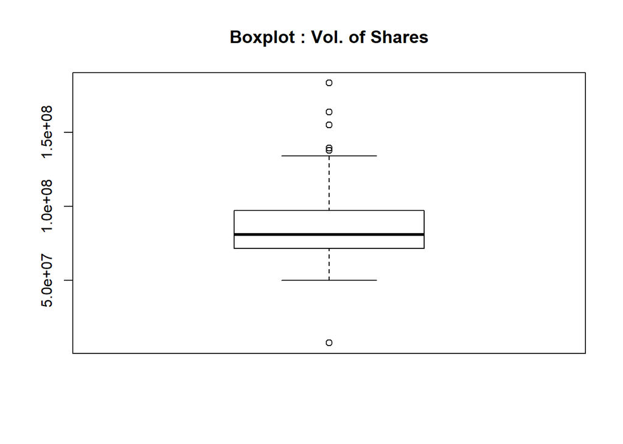

```r
boxplot(amazon$Volume,main = "Boxplot : Vol. of Shares")
```

Checking the distribution of Volume

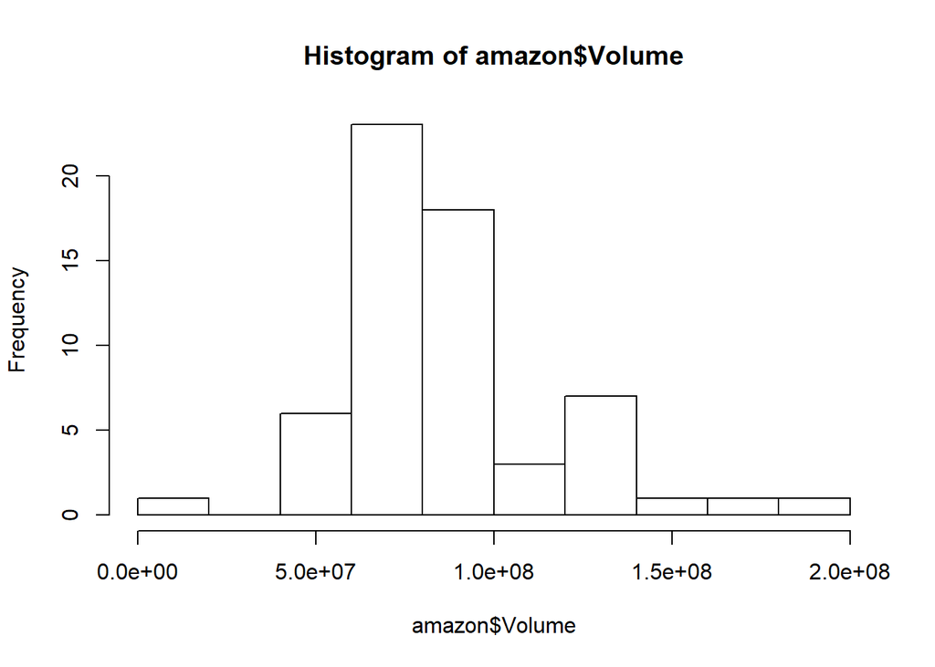

```r
hist(amazon$Volume)
```

The Series is the volume of shares sold

```r
amazon.vol <- amazon %>%
                select (Volume)

amazon.vol.ts<-as.ts(amazon.vol)
```

# Vol. forecasting

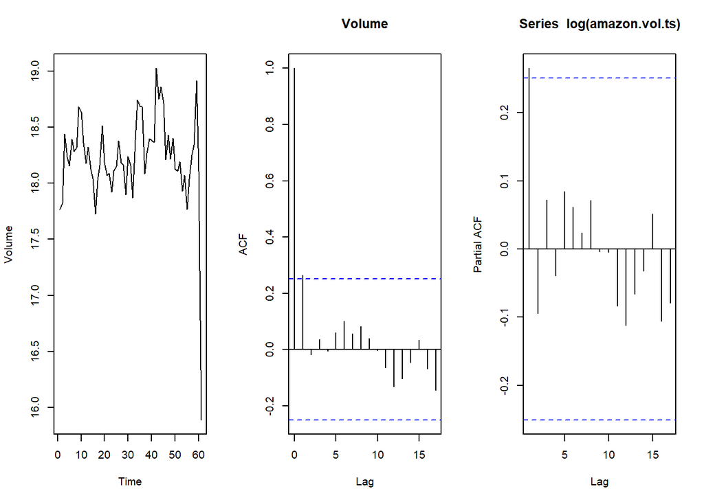

```r
par(mfrow=c(1,3))
plot(log(amazon.vol.ts))
acf(log(amazon.vol.ts))
pacf(log(amazon.vol.ts))
```

- The plots suggests that the series is stationary
- The PACF plot suggests that the series might be generated from MA1
- The ACF plot suggests that the series might be generated from AR1 or AR2

** Lets start with checking if the series is stationary ** # ADF Test

```r
adf.test(amazon.vol.ts,k=1)
```

```
##
##  Augmented Dickey-Fuller Test
##
## data:  amazon.vol.ts
## Dickey-Fuller = -3.7162, Lag order = 1, p-value = 0.03089
## alternative hypothesis: stationary
```

The ADF suggests that the series is stationary and we do not need to take difference

# Model Fitting

Model with AR1

```r
arima100 <- arima(amazon.vol.ts,order=c(1,0,0))
arima100
```

```
##
## Call:
## arima(x = amazon.vol.ts, order = c(1, 0, 0))
##
## Coefficients:
##          ar1  intercept
##       0.5067   86379742
## s.e.  0.1202    6727489
##
## sigma^2 estimated as 6.809e+14:  log likelihood = -1128.41,  aic = 2262.83
```

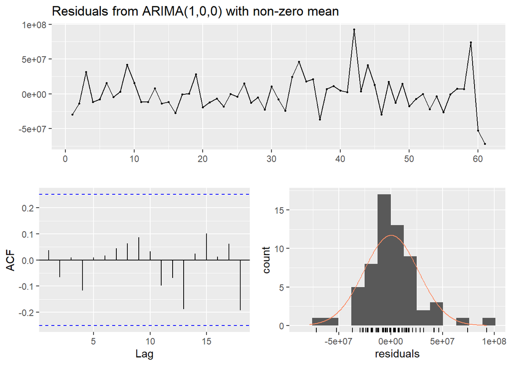

```
##
##  Ljung-Box test
##
## data:  Residuals from ARIMA(1,0,0) with non-zero mean
## Q* = 2.4155, df = 8, p-value = 0.9656
##
## Model df: 2.   Total lags used: 10
```

```r
checkresiduals(arima100)
```

- The model seems to fit the data well
- The ACF plot suggests that the residuals fit well
- The residuals are also normally distributed

Now we can check MA1 model Model with MA1

```r
arima001 <- arima(amazon.vol.ts,order=c(0,0,1))
arima001
```

```
##
## Call:
## arima(x = amazon.vol.ts, order = c(0, 0, 1))
##
## Coefficients:
##          ma1  intercept
##       0.4906   87706490
## s.e.  0.1074    4856016
##
## sigma^2 estimated as 6.902e+14:  log likelihood = -1128.82,  aic = 2263.64
```

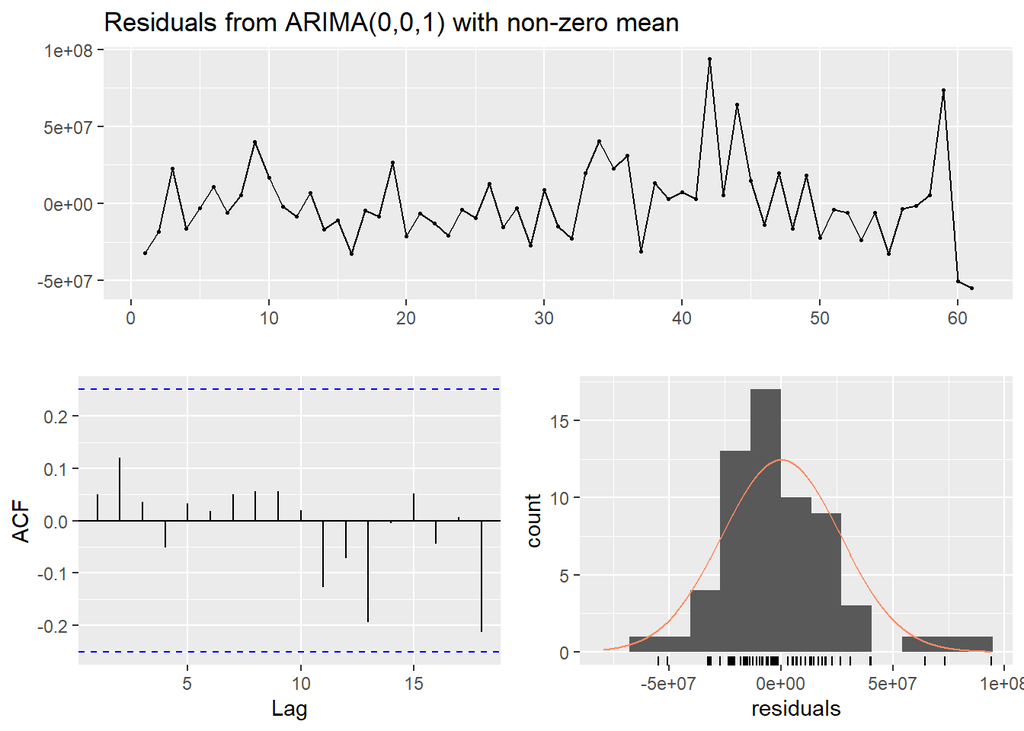

```
##
##  Ljung-Box test
##
## data:  Residuals from ARIMA(0,0,1) with non-zero mean
## Q* = 2.1613, df = 8, p-value = 0.9757
##
## Model df: 2.   Total lags used: 10
```

```r
checkresiduals(arima001)
```

- The model seems to fit the data well
- The ACF plot suggests that the residuals fit well
- The residuals are also normally distributed

Now we can check AR1 and MA1 model Model with AR1 and MA1

```r
arima101 <- arima(amazon.vol.ts,order=c(1,0,1))
arima101
```

```
##
## Call:
## arima(x = amazon.vol.ts, order = c(1, 0, 1))
##
## Coefficients:
##          ar1     ma1  intercept
##       0.3647  0.1835   86833181
## s.e.  0.2754  0.2828    6378879
##
## sigma^2 estimated as 6.759e+14:  log likelihood = -1128.19,  aic = 2264.39
```

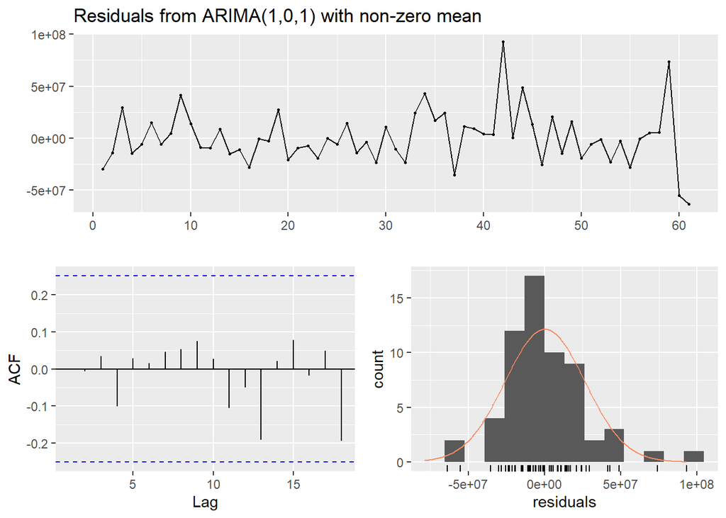

```
##
##  Ljung-Box test
##
## data:  Residuals from ARIMA(1,0,1) with non-zero mean
## Q* = 1.6747, df = 7, p-value = 0.9756
##
## Model df: 3.   Total lags used: 10
```

```r
checkresiduals(arima101)
```

- The model seems to fit the data well
- The ACF plot suggests that the residuals fit well
- The residuals are also normally distributed

Initially we also observed a small spike at 2nd position in ACF plot suggesting that there might be AR2 component as well

Now we can check AR2 model Model with AR2

```r
arima200 <- arima(amazon.vol.ts,order=c(2,0,0))
arima200
```

```
##
## Call:
## arima(x = amazon.vol.ts, order = c(2, 0, 0))
##
## Coefficients:
##          ar1      ar2  intercept
##       0.5493  -0.0908   86826769
## s.e.  0.1357   0.1368    6007412
##
## sigma^2 estimated as 6.759e+14:  log likelihood = -1128.2,  aic = 2264.39
```

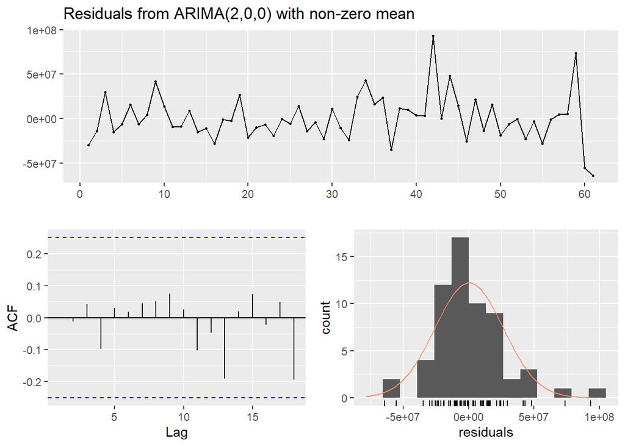

```
##
##  Ljung-Box test
##
## data:  Residuals from ARIMA(2,0,0) with non-zero mean
## Q* = 1.6767, df = 7, p-value = 0.9756
##
## Model df: 3.   Total lags used: 10
```

```r
checkresiduals(arima200)
```

- The model seems to fit the data well
- The ACF plot suggests that the residuals fit well
- The residuals are also normally distributed

Let’s try the auto-arima function and check the output

```r
auto.arima.model <- auto.arima(amazon.vol.ts)
auto.arima.model
```

```
## Series: amazon.vol.ts
## ARIMA(1,0,0) with non-zero mean
##
## Coefficients:
##          ar1      mean
##       0.5067  86379742
## s.e.  0.1202   6727489
##
## sigma^2 estimated as 7.04e+14:  log likelihood=-1128.41
## AIC=2262.83   AICc=2263.25   BIC=2269.16
```

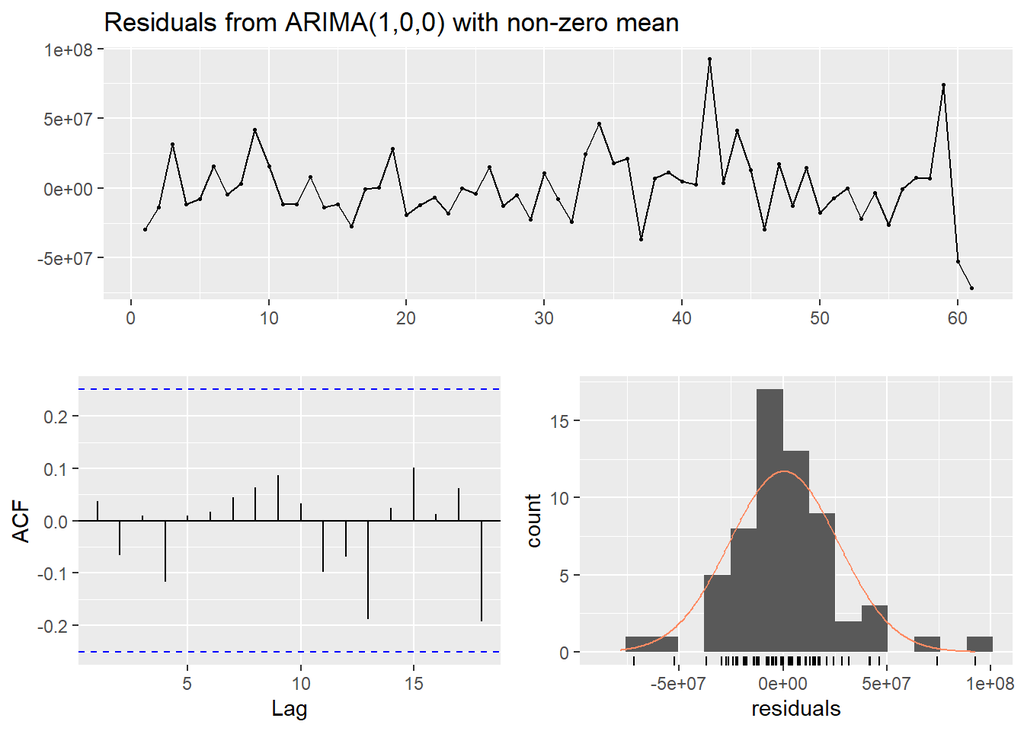

```
##
##  Ljung-Box test
##
## data:  Residuals from ARIMA(1,0,0) with non-zero mean
## Q* = 2.4155, df = 8, p-value = 0.9656
##
## Model df: 2.   Total lags used: 10
```

```r
checkresiduals(auto.arima.model)
```

AutoARIMA suggests that the model is generated from AR1 series which was our initial understanding.

Let’s compare the different AIC values

```r
Models <- rbind('AR1', 'MA1', 'AR1 MA1', 'AR2')

AIC <- rbind(arima100$aic,arima001$aic,arima101$aic,arima200$aic)


Summary <- data.frame(Models,AIC)
Summary
```

```
##    Models      AIC
## 1     AR1 2262.830
## 2     MA1 2263.638
## 3 AR1 MA1 2264.388
## 4     AR2 2264.392
```

The AIC metric suggests that AR1 has smallest AIC value and we go ahead with this model

# Predictions

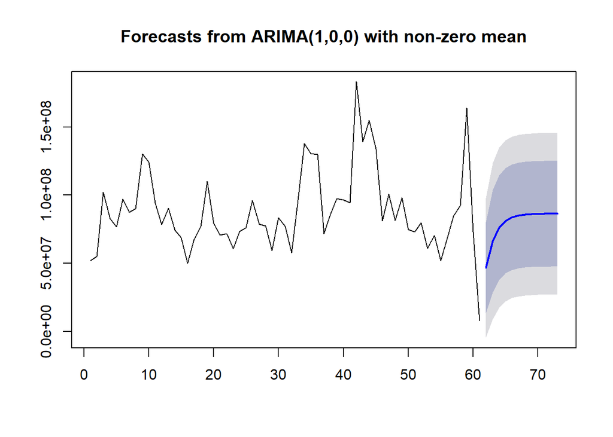

```r
plot(forecast(arima100,h=12))
```

# Next Steps:

- We will split the data into test and validation to tune the model performance
- Explore if VAR can be used to analyze the correlation between Closing price and Volume of shares traded
- R-Shiny app to include the filter to choose the time period